# Zadanie domowe 6

```python
from sklearn.cluster import Birch, SpectralClustering
from sklearn import datasets, metrics

import numpy as np
import pandas as pd

import seaborn as sns
import matplotlib.pyplot as plt

import warnings

warnings.filterwarnings('ignore')

plt.rcParams['figure.figsize']=[25,17]
```

# Wstęp

Porównania dokonam na trzech zbiorach ze sklearn:

- Moons - 2 klastry
- Circles - 2 klastry
- Blobs - 10 klastrów

Wybrałem 4 miary jakości klasteryzacji:

- external:
  - **Rand Statistic**: `metrics.adjusted_rand_score`
  - **Folkes and Mallows index**: `metrics.fowlkes_mallows_score`
- internal:
  - **Silhouette Coefficient**: `metrics.silhouette_score`
  - **Davies Bouldin index**: `metrics.davies_bouldin_score`

# Zbiory

```python
seed = 101110

Moons = datasets.make_moons(1000, noise=0.1, random_state=seed)
Circles = datasets.make_circles(1000, noise=0.05, random_state=seed)
Blobs = datasets.make_blobs(1000, centers = 10, random_state=seed)
```

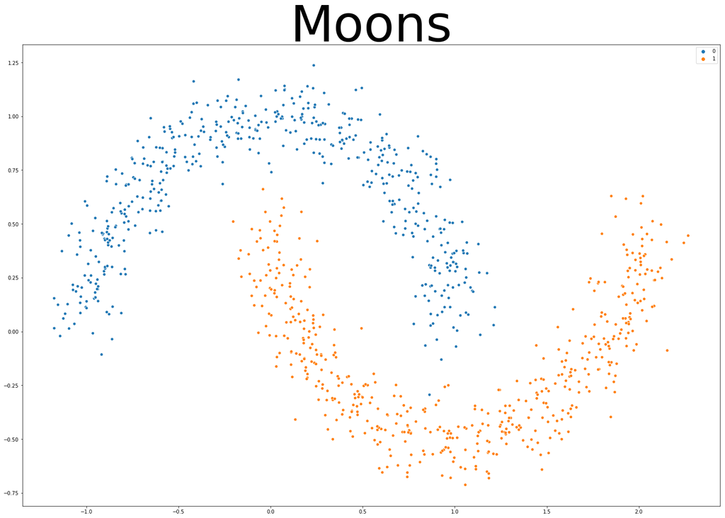

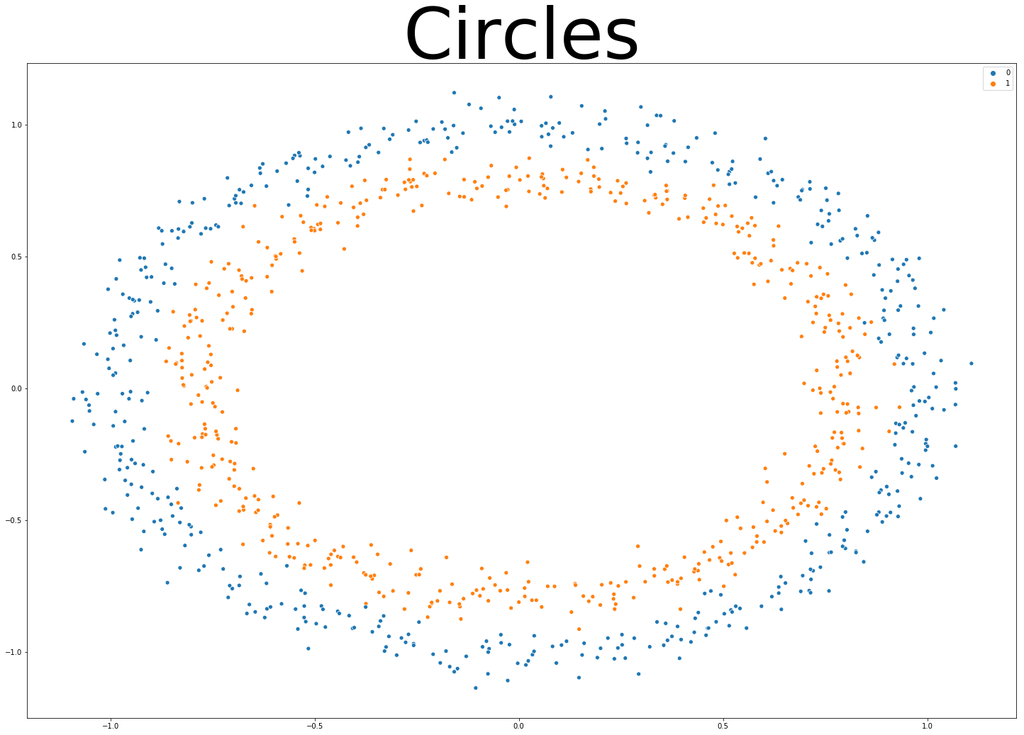

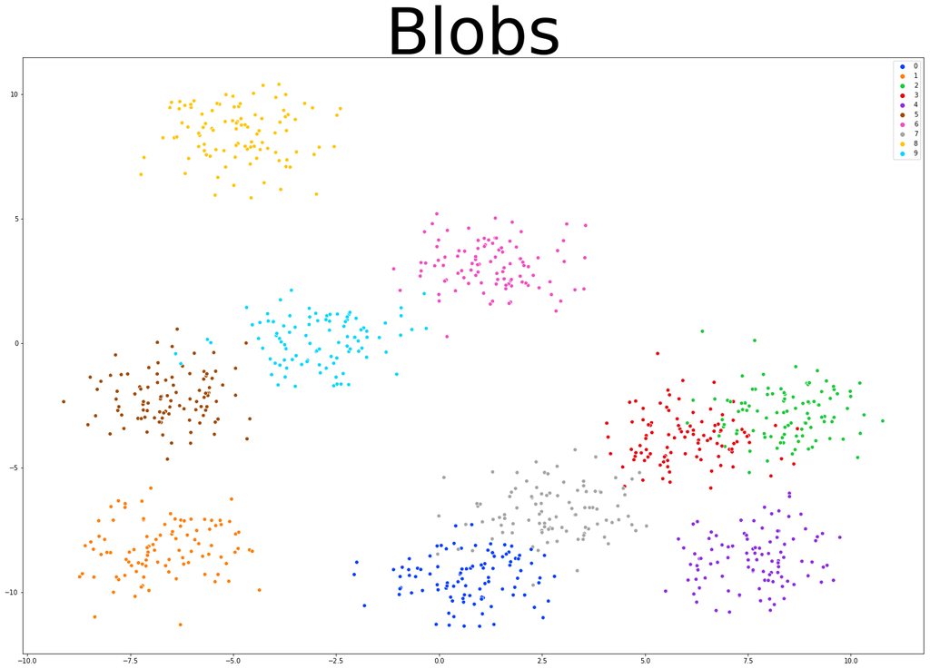

```python
sns.scatterplot(*Moons[0].T, Moons[1])
plt.title('Moons',size=100)
plt.show()
sns.scatterplot(*Circles[0].T, Circles[1])
plt.title('Circles',size=100)
plt.show()
sns.scatterplot(*Blobs[0].T, Blobs[1], palette=sns.color_palette('bright'))
plt.title('Blobs',size=100)
plt.show()
```

# Klasteryzacje

```python
b_moons = Birch(n_clusters=2)
s_moons = SpectralClustering(n_clusters=2)

b_moons.fit(Moons[0])
s_moons.fit(Moons[0])

b_circles = Birch(n_clusters=2)
s_circles = SpectralClustering(n_clusters=2)

b_circles.fit(Circles[0])
s_circles.fit(Circles[0])

b_blobs = Birch(n_clusters=10)
s_blobs = SpectralClustering(n_clusters=10)

b_blobs.fit(Blobs[0])
s_blobs.fit(Blobs[0])
```

```
SpectralClustering(affinity='rbf', assign_labels='kmeans', coef0=1, degree=3,
          eigen_solver=None, eigen_tol=0.0, gamma=1.0, kernel_params=None,
          n_clusters=10, n_init=10, n_jobs=None, n_neighbors=10,
          random_state=None)
```

# Statystyki

```python
def statistics(data, clust1, clust2):
    c1_randstat = metrics.adjusted_rand_score(data[1], clust1.labels_)
    c2_randstat = metrics.adjusted_rand_score(data[1], clust2.labels_)

    c1_fm = metrics.fowlkes_mallows_score(data[1], clust1.labels_)
    c2_fm = metrics.fowlkes_mallows_score(data[1], clust2.labels_)

    c1_s = metrics.silhouette_score(data[0], clust1.labels_)
    c2_s = metrics.silhouette_score(data[0], clust2.labels_)

    c1_db = metrics.davies_bouldin_score(data[0], clust1.labels_)
    c2_db = metrics.davies_bouldin_score(data[0], clust2.labels_)

    return pd.DataFrame({
        'RandStat': [c1_randstat, c2_randstat],
        'Folkes_Mallows': [c1_fm, c2_fm],
        'Silhoutte': [c1_s, c2_s],
        'Davies_Bouldin': [c1_db, c2_db]
    })
```

## Moons

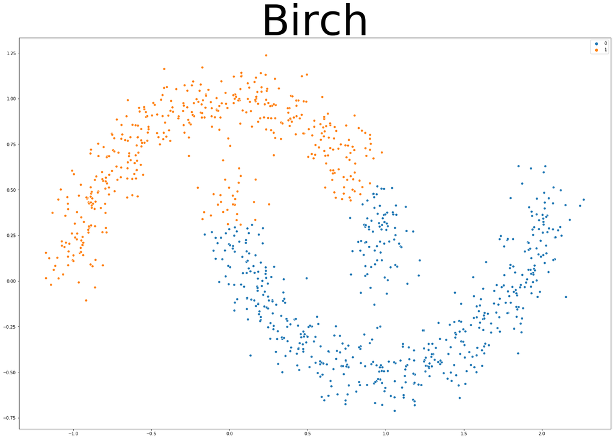

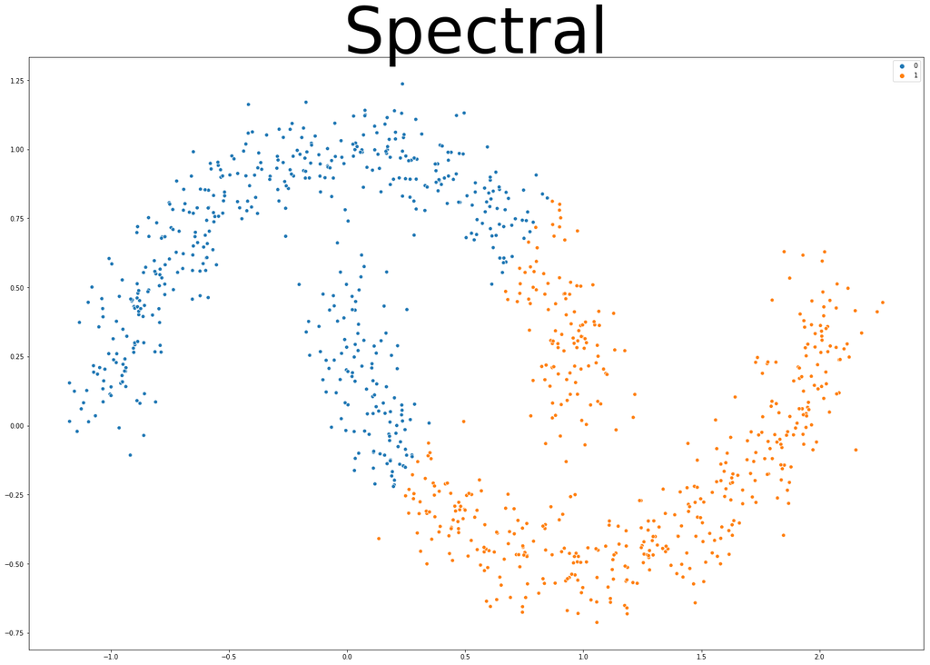

```python
sns.scatterplot(*Moons[0].T, b_moons.labels_)
plt.title('Birch', size=100)
plt.show()

sns.scatterplot(*Moons[0].T, s_moons.labels_)
plt.title('Spectral', size=100)
plt.show()
```

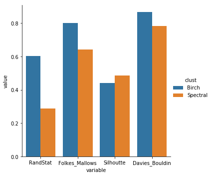

```python
stat = statistics(Moons, b_moons, s_moons)
stat['clust']=['Birch', 'Spectral']
stat = stat.melt(id_vars=['clust'])
sns.catplot(x='variable', y = 'value', hue = 'clust', data=stat,kind='bar')
plt.show()
```

## Circles

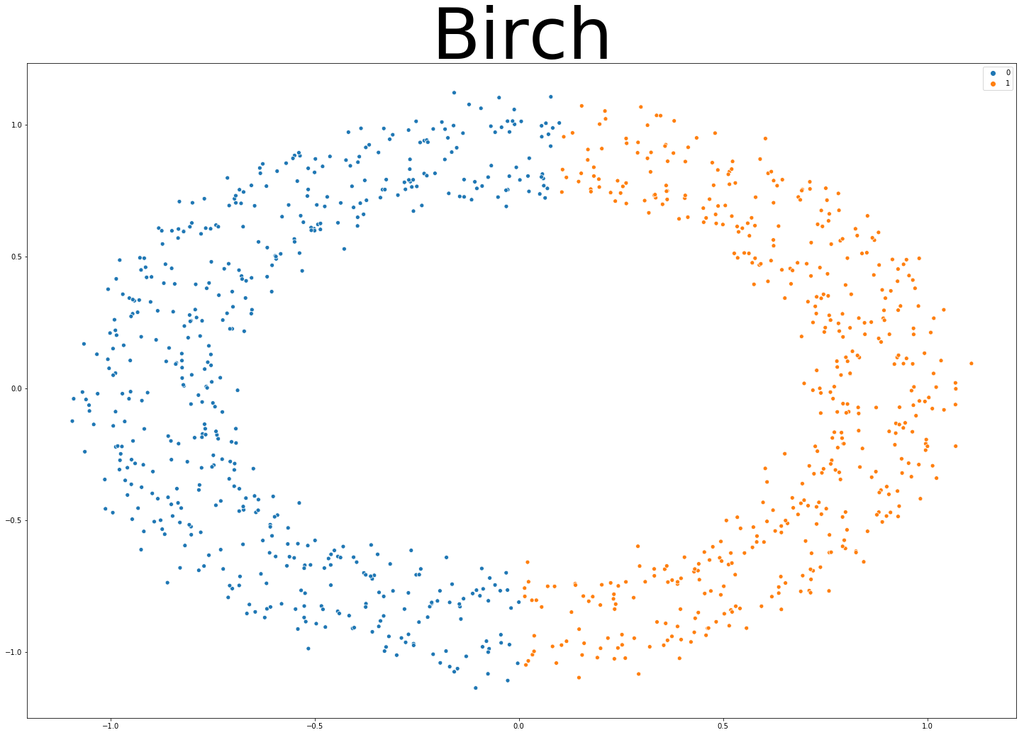

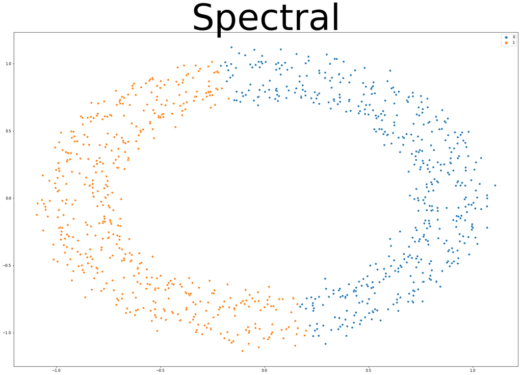

```python
sns.scatterplot(*Circles[0].T, b_circles.labels_)
plt.title('Birch', size=100)
plt.show()

sns.scatterplot(*Circles[0].T, s_circles.labels_)
plt.title('Spectral', size=100)
plt.show()
```

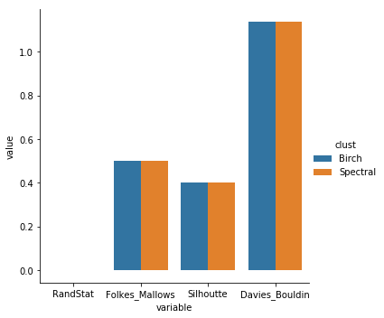

```python
stat = statistics(Circles, b_circles, s_circles)
stat['clust']=['Birch', 'Spectral']
stat = stat.melt(id_vars=['clust'])
sns.catplot(x='variable', y = 'value', hue = 'clust', data=stat,kind='bar')
plt.show()
```

### Wnioski

Obie klasteryzacje są praktycznie identyczne. *Rand Statistic* daje wartość bliską zeru, co oznacza, że etykietowanie jest porównywalne z losowym. Wysoka wartość miary *Daviesa Bouldina* pokazuje, że oba klastry są bardzo do siebie podobne.

## Blobs

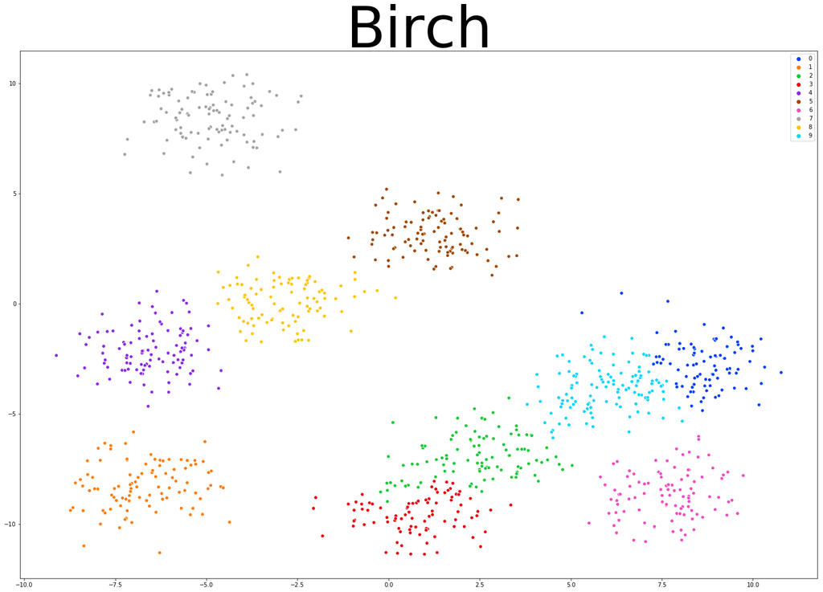

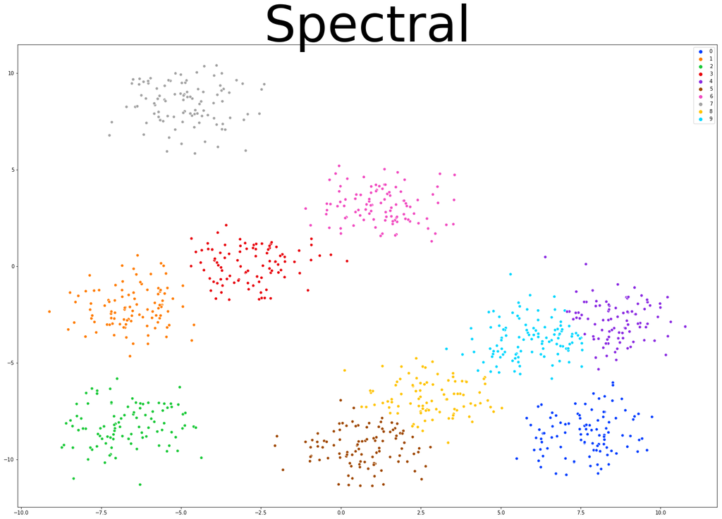

```python
sns.scatterplot(*Blobs[0].T, b_blobs.labels_, palette=sns.color_palette('bright'))
plt.title('Birch', size=100)
plt.show()

sns.scatterplot(*Blobs[0].T, s_blobs.labels_, palette=sns.color_palette('bright'))
plt.title('Spectral', size=100)
plt.show()
```

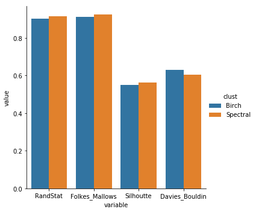

```python
stat = statistics(Blobs, b_blobs, s_blobs)
stat['clust']=['Birch', 'Spectral']
stat = stat.melt(id_vars=['clust'])
sns.catplot(x='variable', y = 'value', hue = 'clust', data=stat,kind='bar')
plt.show()
```

### Wnioski

W tym przypadku oba algorytmy poradziły sobie równie dobrze co widać również po miarach.

# Wnioski ogólne

Różne miary mogą dawać odmienne wynniki dla tych samych zbiorów i algorytmów klasteryzacji. Każda z tych miar zwraca uwagę na trochę inny aspekt *dobrej klasteryzacji*. Ponieważ jest wiele możliwych klasteryzacji tego samego zbioru i nie istnieje nalepszy podział, dobrze jest ocenić klasteryzację wieloma różnymi miarami i zdecydować, co jest w tej sytuacji najbardziej pożądaną cechą.